# Упражнение 7

Дунашов Константин

11 05 2021

Необходимо построить две модели:

зависимости непрерывного отклика от одного непрерывного предиктора; зависимости вероятности (логит) от одного непрерывного предиктора. Для каждой модели:

1 Указать смысл переменных модели, метод оценки и настроечный параметр (степень полинома, гиперпараметр λ, ширина окна s, число узлов – в зависимости от метода).

2 Подогнать модель на всех наблюдениях, меняя значение настроечного параметра.

3 Обосновать оптимальное значение настроечного параметра подходящим методом (кросс-валидация, ANOVA).

4 Сделать прогноз на обучающую выборку по лучшей модели: модельные значения и ошибки прогноза.

5 Построить график с фактическими наблюдениями, модельной кривой и 95% доверительными интервалами прогноза.

Вариант - 10

Модели: натуральный кубический сплайн. Данные: Auto {ISLR}.

Работаем с набором данных по расходу бензина, лошадиной силе и другой информация для 392 автомобилей. Присоединяем его к пространству имён функцией attach(), и дальше обращаемся напрямую к столбцам таблицы.

```r
attach(Auto)
```

Работаем со столбцами: * displacement - Объем двигателя (куб. Дюймов); * acceleration - Время ускорения от 0 до 60 миль в час (сек.).

# Натуральный кубический сплайн

Судя по графику ниже, взаимосвязь объема двигателя и времени ускорения нелинейна. Наблюдается также группа наблюдений с высоким значением displacement, граница проходит примерно на уровне 280.

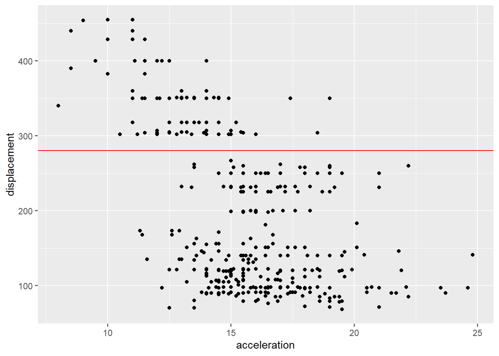

```r
gp <- ggplot(data = Auto, aes(x = acceleration, y = displacement))
gp <- gp + geom_point() + geom_abline(slope = 0, intercept = 280, col = 'red')
gp
```

# Зависимость объема двигателя от времени ускорения от 0 до 60 миль в час (модель 1)

Построим кубический сплайн с тремя узлами.

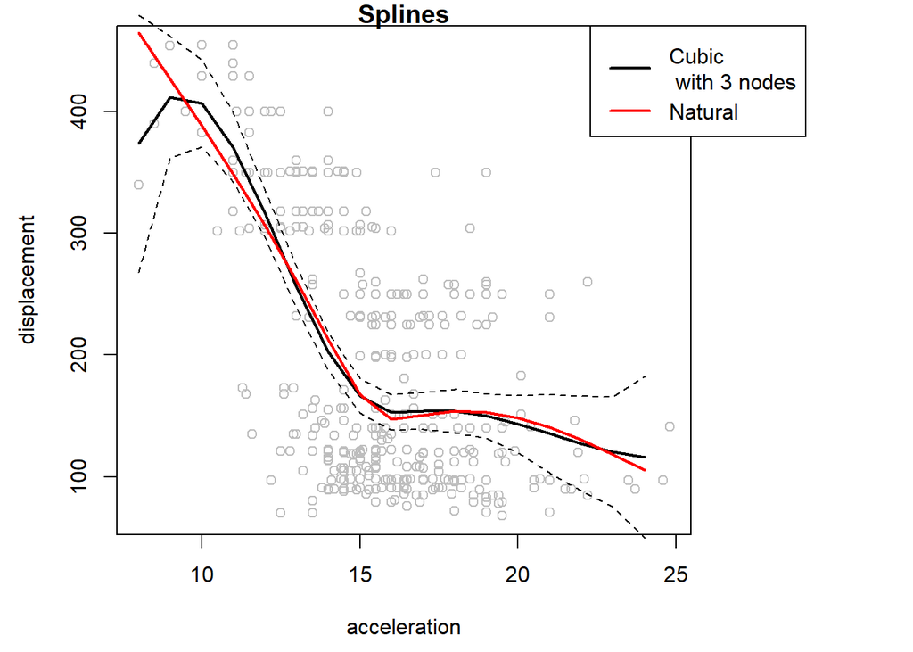

```r
# Границы изменения переменной acceleration
acclims <- range(acceleration)

# значения acceleration, для которых делаем прогноз (от min до max с шагом 1)
acc.grid <- seq(from = acclims[1], to = acclims[2])
# кубический сплайн с тремя узлами, 6 степеней свободы
fit <- lm(displacement ~ bs(acceleration, df = 6), data = Auto)
# прогноз
preds.spl <- predict(fit, newdata = list(acceleration = acc.grid), se = T)

# натуральный сплайн
fit2 <- lm(displacement ~ ns(acceleration, df = 4), data = Auto)
preds.spl2 <- predict(fit2, newdata = list(acceleration = acc.grid), se = T)

par(mfrow = c(1, 1), mar = c(4.5, 4.5, 1, 8.5), oma = c(0, 0, 0, 0), xpd = T)

# наблюдения
plot(acceleration, displacement, col = 'grey')

# модель кубического сплайна
lines(acc.grid, preds.spl$fit, lwd = 2)

# доверительный интервал
lines(acc.grid, preds.spl$fit + 2*preds.spl$se, lty = 'dashed')
lines(acc.grid, preds.spl$fit - 2*preds.spl$se, lty = 'dashed')

# натуральный сплайн
lines(acc.grid, preds.spl2$fit, col = 'red', lwd = 2)

# легенда
legend("topright", inset = c(-0.2, 0),
       c('Cubic \n with 3 nodes', 'Natural'),
       lwd = rep(2, 2), col = c('black', 'red'))

# заголовок
title("Splines")
```

# Определение оптимального настроечного параметра (модель 1)

```r
fit.1 <- lm(displacement ~ bs(acceleration, df = 3), data = Auto)
fit.2 <- lm(displacement ~ bs(acceleration, df = 4), data = Auto)
fit.3 <- lm(displacement ~ bs(acceleration, df = 5), data = Auto)
fit.4 <- lm(displacement ~ bs(acceleration, df = 6), data = Auto)
fit.5 <- lm(displacement ~ bs(acceleration, df = 7), data = Auto)


# Дисперсионный анализ
round(anova(fit.1, fit.2, fit.3, fit.4, fit.5), 2)
```

```
## Analysis of Variance Table
##
## Model 1: displacement ~ bs(acceleration, df = 3)
## Model 2: displacement ~ bs(acceleration, df = 4)
## Model 3: displacement ~ bs(acceleration, df = 5)
## Model 4: displacement ~ bs(acceleration, df = 6)
## Model 5: displacement ~ bs(acceleration, df = 7)
##   Res.Df     RSS Df Sum of Sq     F Pr(>F)
## 1    388 2611074
## 2    387 2508059  1    103015 16.12 <2e-16 ***
## 3    386 2461081  1     46978  7.35   0.01 **
## 4    385 2462412  1     -1331
## 5    384 2453918  1      8494  1.33   0.25
## ---
## Signif. codes:  0 '***' 0.001 '**' 0.01 '*' 0.05 '.' 0.1 ' ' 1
```

```r
# Лучшая модель со степенью свободы = 5
best.fit.1 <- fit.3
```

# Прогноз на обучающую выборку по лучшей модели (модель 1)

```r
# Прогноз по лучшей модели
preds <- predict(best.fit.1, data.frame(acceleration = acc.grid), se = T)

# Границы доверительного интервала для площади нерозничных торговых площадей
se.bands <- cbind(lower.bound = preds$fit - 2*preds$se.fit,
                  upper.bound = preds$fit + 2*preds$se.fit)

# Смотрим результат
round(head(se.bands), 2)
```

```
##   lower.bound upper.bound
## 1      266.78      463.41
## 2      362.04      461.95
## 3      378.43      441.74
## 4      347.73      399.57
## 5      297.44      336.43
## 6      239.99      268.47
```

```r
# Стандартные ошибки
round(preds$se.fit, 2)
```

```
##     1     2     3     4     5     6     7     8     9    10    11    12    13
## 49.16 24.98 15.83 12.96  9.75  7.12  7.03  6.25  6.07  7.40  7.43  8.52 11.60
##    14    15    16    17
## 14.87 17.43 21.57 33.10
```

# График с фактическими наблюдениями, модельной кривой и 95% доверительными интервалами прогноза (модель 1)

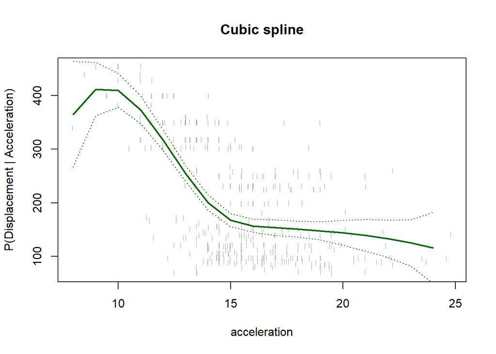

```r
# Сетка для графика
plot(acceleration, displacement, xlim = acclims, type = 'n',
     ylab = 'P(Displacement | Acceleration)')

# Фактические наблюдения показываем засечки
points(jitter(acceleration), displacement, cex = 0.5, pch = '|', col = 'darkgrey')

pfit <- preds$fit
# Модель
lines(acc.grid, pfit, lwd = 2, col = 'darkgreen')

# Доверительные интервалы
matlines(acc.grid, se.bands, lwd = 1, col = 'darkgreen', lty = 3)

# Заголовок
title('Cubic spline')
```

# Зависимость объема двигателя > 280 от времени ускорения от 0 до 60 миль в час (модель 2)

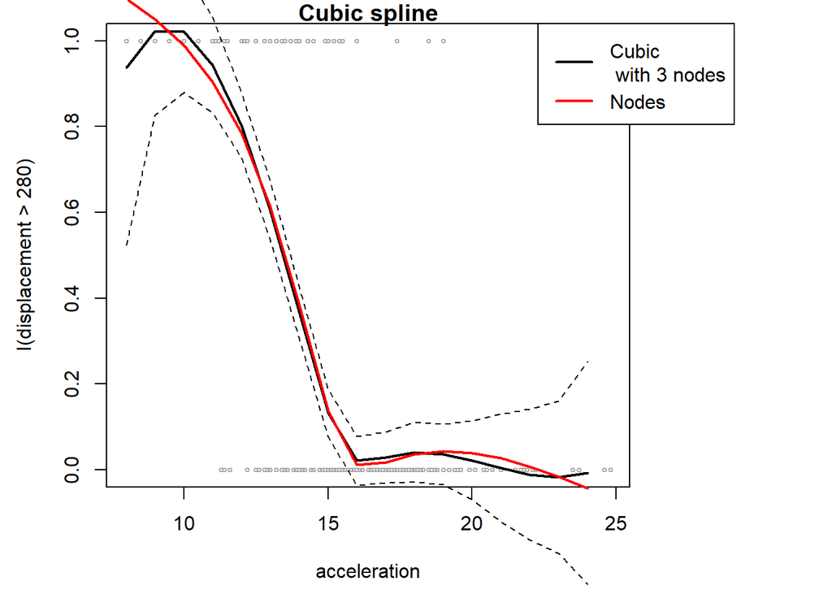

```r
par(mfrow = c(1, 1), mar = c(4.5, 4.5, 1, 8.5), oma = c(0, 0, 0, 0), xpd = T)

# график
plot(acceleration, I(displacement > 280), xlim = acclims, cex = 0.5, col = 'darkgrey')

title('Cubic spline')

fit2.1 <- lm(I(displacement > 280) ~ bs(acceleration, df = 6), data = Auto)
# прогноз
preds.spl.2 <- predict(fit2.1, newdata = list(acceleration = acc.grid), se = T)

# натуральный сплайн
fit2.2 <- lm(I(displacement > 280) ~ ns(acceleration, df = 4), data = Auto)
preds.spl2.2 <- predict(fit2.2, newdata = list(acceleration = acc.grid), se = T)

# модель кубического сплайна
lines(acc.grid, preds.spl.2$fit, lwd = 2)

# доверительный интервал
lines(acc.grid, preds.spl.2$fit + 2*preds.spl.2$se, lty = 'dashed')
lines(acc.grid, preds.spl.2$fit - 2*preds.spl.2$se, lty = 'dashed')

# натуральный сплайн
lines(acc.grid, preds.spl2.2$fit, col = 'red', lwd = 2)

# легенда
legend("topright", inset = c(-0.2, 0),
       c('Cubic \n with 3 nodes', 'Nodes'),
       lwd = rep(2, 2), col = c('black', 'red'))
```

# Определение оптимального настроечного параметра (модель 2)

```r
fit.1 <- lm(I(displacement > 280) ~ bs(acceleration, df = 3), data = Auto)
fit.2 <- lm(I(displacement > 280) ~ bs(acceleration, df = 4), data = Auto)
fit.3 <- lm(I(displacement > 280) ~ bs(acceleration, df = 5), data = Auto)
fit.4 <- lm(I(displacement > 280) ~ bs(acceleration, df = 6), data = Auto)
fit.5 <- lm(I(displacement > 280) ~ bs(acceleration, df = 7), data = Auto)


# Дисперсионный анализ
round(anova(fit.1, fit.2, fit.3, fit.4, fit.5), 2)
```

```
## Analysis of Variance Table
##
## Model 1: I(displacement > 280) ~ bs(acceleration, df = 3)
## Model 2: I(displacement > 280) ~ bs(acceleration, df = 4)
## Model 3: I(displacement > 280) ~ bs(acceleration, df = 5)
## Model 4: I(displacement > 280) ~ bs(acceleration, df = 6)
## Model 5: I(displacement > 280) ~ bs(acceleration, df = 7)
##   Res.Df   RSS Df Sum of Sq     F Pr(>F)
## 1    388 41.22
## 2    387 38.27  1      2.95 30.16 <2e-16 ***
## 3    386 38.19  1      0.08  0.79   0.37
## 4    385 37.72  1      0.48  4.88   0.03 *
## 5    384 37.58  1      0.14  1.38   0.24
## ---
## Signif. codes:  0 '***' 0.001 '**' 0.01 '*' 0.05 '.' 0.1 ' ' 1
```

```r
# Лучшая модель со степенью свободы = 6
best.fit.2 <- fit.4
```

# Прогноз на обучающую выборку по лучшей модели (модель 2)

```r
# Прогноз по лучшей модели
preds <- predict(best.fit.2, data.frame(acceleration = acc.grid), se = T)

# Границы доверительного интервала для площади нерозничных торговых площадей
se.bands <- cbind(lower.bound = preds$fit - 2*preds$se.fit,
                  upper.bound = preds$fit + 2*preds$se.fit)

# Смотрим результат
round(head(se.bands), 2)
```

```
##   lower.bound upper.bound
## 1        0.52        1.35
## 2        0.83        1.22
## 3        0.88        1.16
## 4        0.83        1.06
## 5        0.73        0.88
## 6        0.54        0.67
```

```r
# Стандартные ошибки
round(preds$se.fit, 2)
```

```
##    1    2    3    4    5    6    7    8    9   10   11   12   13   14   15   16
## 0.21 0.10 0.07 0.06 0.04 0.03 0.03 0.03 0.03 0.03 0.03 0.04 0.05 0.06 0.08 0.09
##   17
## 0.13
```

# График с фактическими наблюдениями, модельной кривой и 95% доверительными интервалами прогноза (модель 2)

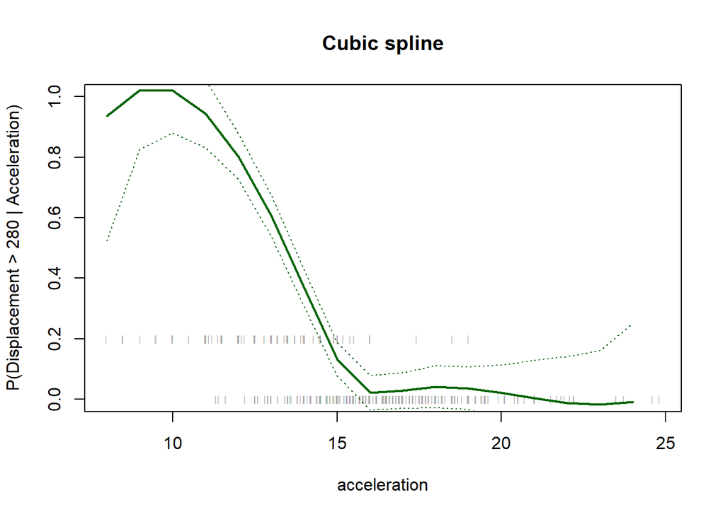

```r
# Сетка для графика
plot(acceleration, I(displacement > 280), xlim = acclims, type = 'n',
     ylab = 'P(Displacement > 280 | Acceleration)')

# Фактические наблюдения показываем засечки
points(jitter(acceleration), I((displacement>280)/5), cex = 0.5, pch = '|', col = 'darkgrey')

pfit <- preds$fit
# Модель
lines(acc.grid, pfit, lwd = 2, col = 'darkgreen')

# Доверительные интервалы
matlines(acc.grid, se.bands, lwd = 1, col = 'darkgreen', lty = 3)

# Заголовок
title('Cubic spline')
```